# ch7-ex-applied

S Zimine

12/5/2017

### Ex 6

#### 6.a

From Asad solution

```r
library(ISLR)
library(boot)

dfmax <- 10
kcv <- 10
all.deltas <- rep(NA, dfmax)
for (i in 1:dfmax) {
  glm.fit <- glm(wage~poly(age, i,raw=TRUE), data=Wage)
  all.deltas[i] = cv.glm(Wage, glm.fit, K=kcv)$delta[2] #10-folkd CV
}

plot(1:dfmax, all.deltas, xlab="Degree", ylab="CV error", type="l", pch=20, lwd=2, main="dataset MSE as a function of polynomial degree in wage~poly(wage,i)")
min.point = min(all.deltas)
print(min.point)
```

```
## [1] 1593.399
```

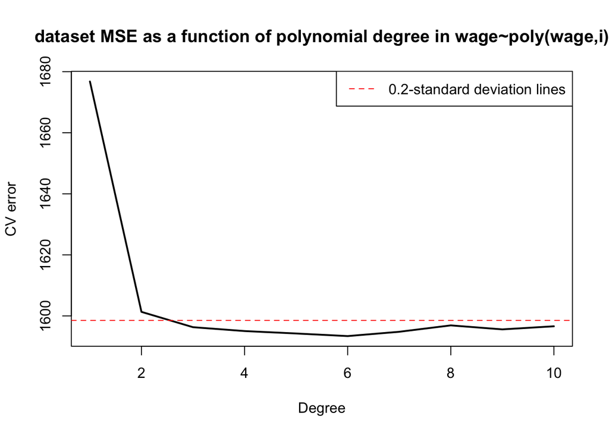

```r
sd.points = sd(all.deltas)
abline(h=min.point + 0.2 * sd.points, col="red", lty="dashed")
abline(h=min.point - 0.2 * sd.points, col="red", lty="dashed")
legend("topright", "0.2-standard deviation lines", lty="dashed", col="red")
```

The plot indicates that $df=3$ is a minimal degrees of freedom with a small enough test MSE.

Lets compare it with `anova()` results.

```r
fit1 <- lm(wage~poly(age,1,raw=TRUE),data=Wage)
fit2 <- lm(wage~poly(age,2,raw=TRUE),data=Wage)
fit3 <- lm(wage~poly(age,3,raw=TRUE),data=Wage)
fit4 <- lm(wage~poly(age,4,raw=TRUE),data=Wage)
fit5 <- lm(wage~poly(age,5,raw=TRUE),data=Wage)
fit6 <- lm(wage~poly(age,6,raw=TRUE),data=Wage)
fit7 <- lm(wage~poly(age,7,raw=TRUE),data=Wage)
fit8 <- lm(wage~poly(age,8,raw=TRUE),data=Wage)
fit9 <- lm(wage~poly(age,9,raw=TRUE),data=Wage)

anova(fit1,fit2,fit3,fit4,fit5,fit6,fit7,fit8,fit9)
```

```
## Analysis of Variance Table
##
## Model 1: wage ~ poly(age, 1, raw = TRUE)
## Model 2: wage ~ poly(age, 2, raw = TRUE)
## Model 3: wage ~ poly(age, 3, raw = TRUE)
## Model 4: wage ~ poly(age, 4, raw = TRUE)
## Model 5: wage ~ poly(age, 5, raw = TRUE)
## Model 6: wage ~ poly(age, 6, raw = TRUE)
## Model 7: wage ~ poly(age, 7, raw = TRUE)
## Model 8: wage ~ poly(age, 8, raw = TRUE)
## Model 9: wage ~ poly(age, 9, raw = TRUE)
##   Res.Df     RSS Df Sum of Sq        F    Pr(>F)
## 1   2998 5022216
## 2   2997 4793430  1    228786 143.8118 < 2.2e-16 ***
## 3   2996 4777674  1     15756   9.9038  0.001666 **
## 4   2995 4771604  1      6070   3.8156  0.050870 .
## 5   2994 4770322  1      1283   0.8062  0.369318
## 6   2993 4766389  1      3932   2.4718  0.116014
## 7   2992 4763834  1      2555   1.6062  0.205123
## 8   2991 4763707  1       127   0.0796  0.777829
## 9   2990 4756703  1      7004   4.4028  0.035963 *
## ---
## Signif. codes:  0 '***' 0.001 '**' 0.01 '*' 0.05 '.' 0.1 ' ' 1
```

`anova()` also shows that the minimul number of degree of freedom is 3.

Plot the fit with the determined number of $df$.

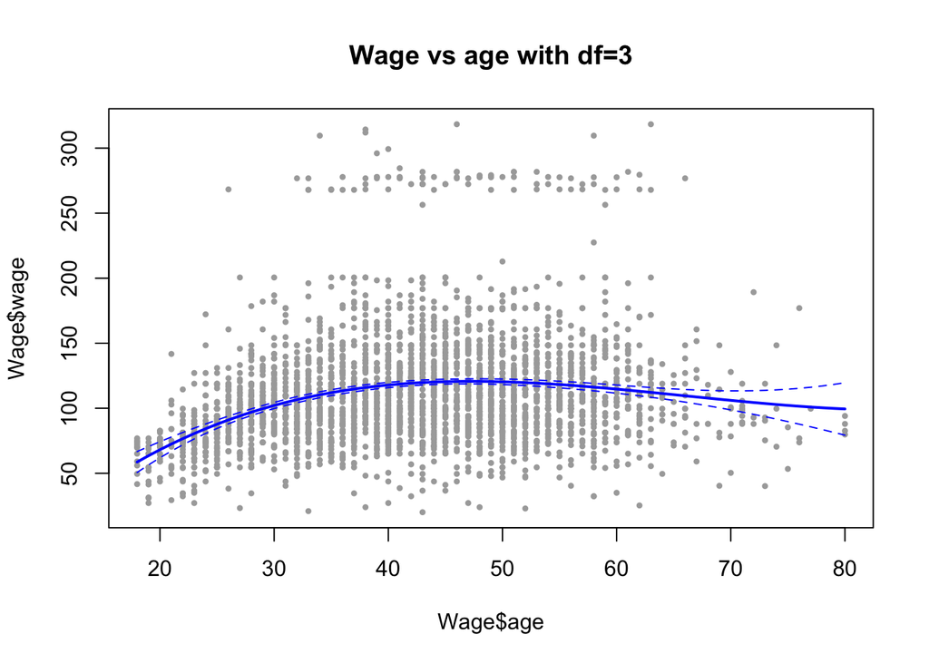

```r
agelims=range(Wage$age)
age.grid=seq(from=agelims[1],to=agelims[2])

fit<- glm(wage~poly(age,3,raw=T),data=Wage)
pred <- predict(fit, newdata=list(age=age.grid),se=TRUE)
se.bands <- cbind(pred$fit+2*pred$se  , pred$fit-2*pred$se )

plot(Wage$age,Wage$wage, main="Wage vs age with df=3", col="darkgray", pch=20, cex=0.7 )
lines(age.grid, pred$fit, lwd=2, col="blue")
matlines(age.grid, se.bands,col="blue", lty=2)
```

### 6.b

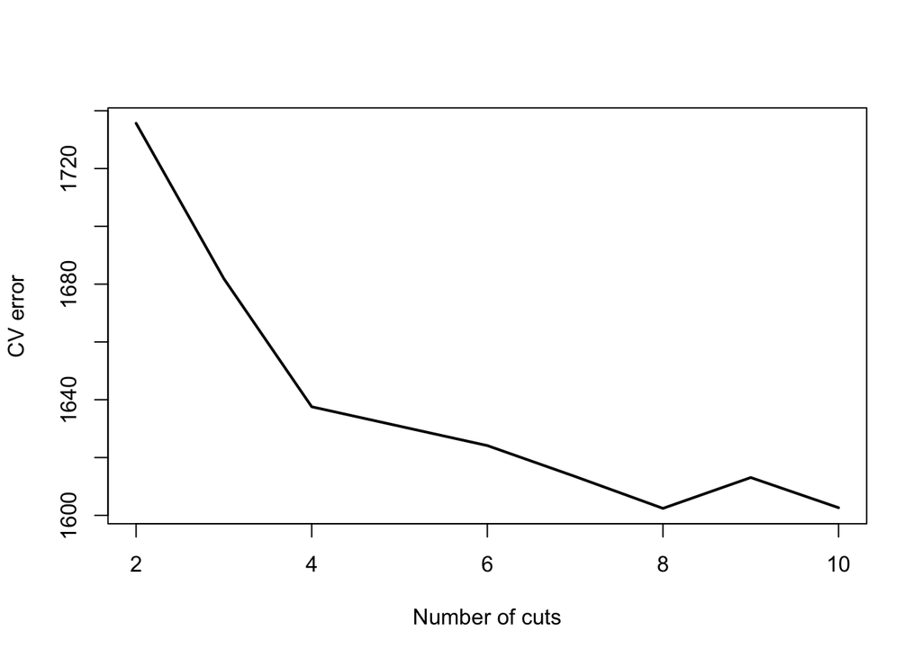

```r
cutmax <- 10
all.cvs = rep(NA, cutmax)
for (i in 2:10) {
  Wage$age.cut = cut(Wage$age, i)
  lm.fit = glm(wage~age.cut, data=Wage)
  all.cvs[i] = cv.glm(Wage, lm.fit, K=10)$delta[2]
}
plot(2:10, all.cvs[-1], xlab="Number of cuts", ylab="CV error", type="l", pch=20, lwd=2)
```

Number of cuts is 8

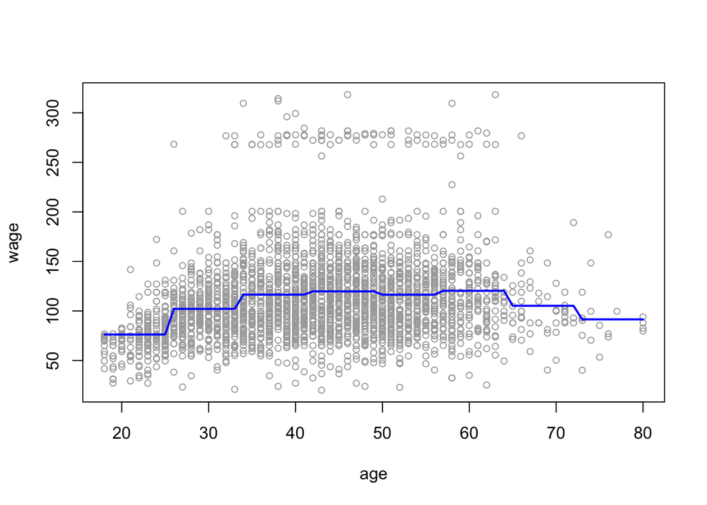

```r
fit <- glm(wage~cut(age,8), data=Wage)
preds <- predict(fit, newdata=list(age=age.grid))
plot(wage~age, data=Wage, col="darkgrey", cex=0.8)
lines(age.grid, preds,  lwd=2,col="blue")
```

### Ex 7

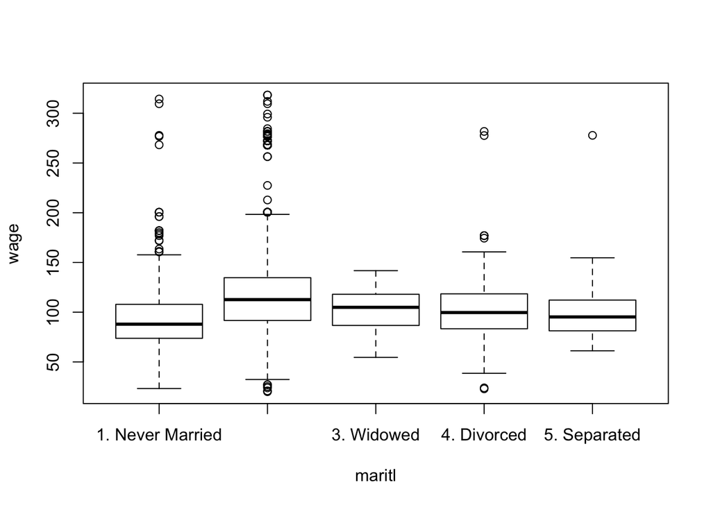

```r
plot(wage~maritl, data=Wage)
```

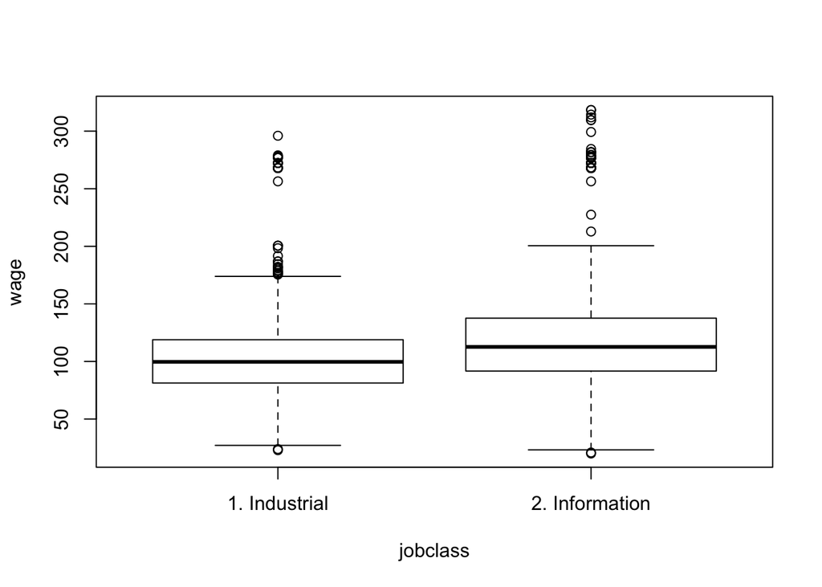

```r
plot(wage~jobclass, data=Wage)
```

From plots it appears a married couple makes more money on average than other groups. It also appears that Informational jobs are higher-wage than Industrial jobs on average.

#### gams

```r
require(gam)
```

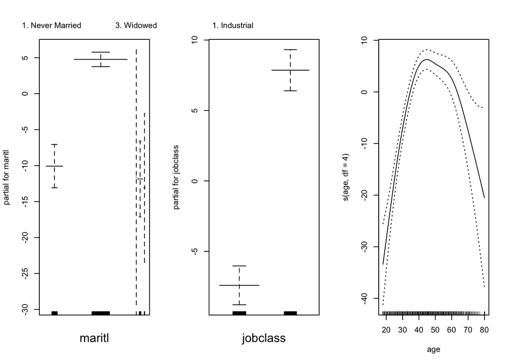

```r
gam1<- gam(wage~maritl+jobclass+s(age,df=4), data=Wage)
par( mfrow=c(1,3))
plot(gam1,se=TRUE)
```

#### Polynomial and Step functions

```r
fit = lm(wage~maritl, data=Wage)
deviance(fit)
```

```
## [1] 4858941
```

```r
fit = lm(wage~jobclass, data=Wage)
deviance(fit)
```

```
## [1] 4998547
```

```r
fit = lm(wage~maritl+jobclass, data=Wage)
deviance(fit)
```

```
## [1] 4654752
```

### Ex 8

The flollow variables were identified as having non-linear relationship

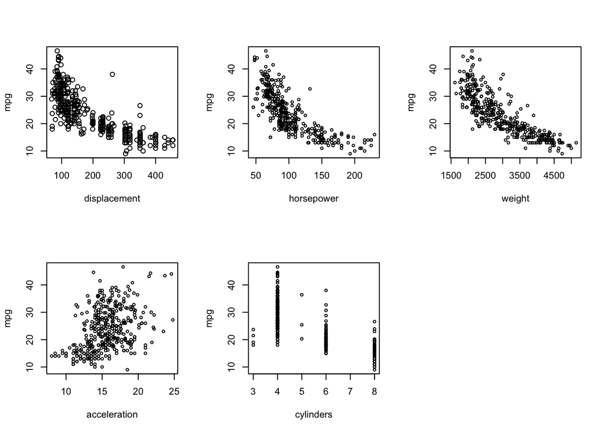

```r
data(Auto)
par(mfrow=c(2,3))
plot(mpg~displacement, data=Auto)
plot(mpg~horsepower, data=Auto, cex=0.6)
plot(mpg~weight, data=Auto, cex=0.6)
plot(mpg~acceleration, data=Auto, cex=0.6)
plot(mpg~cylinders, data=Auto, cex=0.6)
```

Lets examine `cylinders`

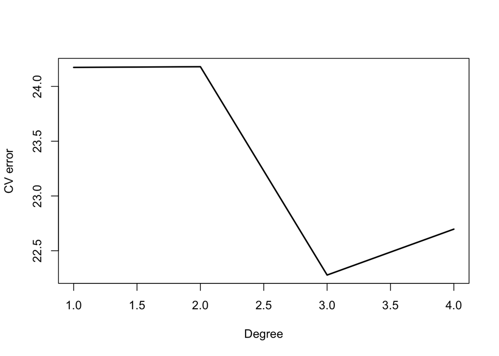

```r
# polynomial regression
maxpd <-4
all.deltas = rep(NA, maxpd)
for (i in 1:maxpd) {
  glm.fit = glm(mpg~poly(cylinders, i), data=Auto)
  all.deltas[i] = cv.glm(Auto, glm.fit, K=10)$delta[2]
}
plot(1:maxpd, all.deltas, xlab="Degree", ylab="CV error", type="l", pch=20, lwd=2)
```

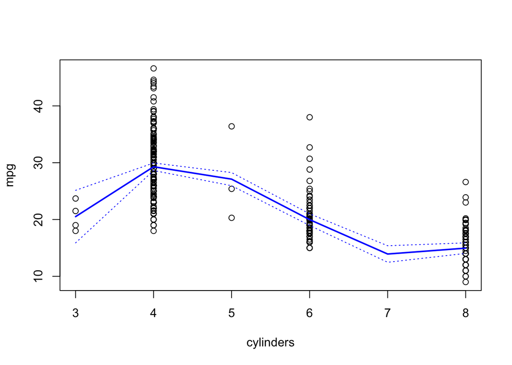

```r
cylr <- range(Auto$cylinders)
cyl.grid <-seq(from=cylr[1], to=cylr[2])

cy.fit = glm(mpg~poly(cylinders, 3), data=Auto) #
cy.preds <- predict(cy.fit, newdata=list(cylinders=cyl.grid),se=TRUE)
cy.se.bands=cbind(cy.preds$fit+2*cy.preds$se.fit ,cy.preds$fit-2*cy.preds$se.fit )

plot(mpg~cylinders,data=Auto)
lines(cyl.grid,cy.preds$fit,lwd=2,col="blue")
matlines(cyl.grid,cy.se.bands,lwd=1,col="blue",lty=3)
```

#### Les study the displacement variable with various approaches

##### Polynomial

```r
rss <- rep(NA,10)
fits <- list()
for (d in 1:10){
  fits[[d]] <- lm(mpg~poly(displacement,d), data=Auto)
  rss[d] <- deviance(fits[[d]])
}
rss
```

```
##  [1] 8378.822 7412.263 7392.322 7391.722 7380.838 7270.746 7089.716
##  [8] 6917.401 6737.801 6610.190
```

```r
which.min(rss)
```

```
## [1] 10
```

train RSS expectedly decreases with an increase of a polynomial degree

```r
anova(fits[[1]],fits[[2]],fits[[3]],fits[[4]])
```

```
## Analysis of Variance Table
##
## Model 1: mpg ~ poly(displacement, d)
## Model 2: mpg ~ poly(displacement, d)
## Model 3: mpg ~ poly(displacement, d)
## Model 4: mpg ~ poly(displacement, d)
##   Res.Df    RSS Df Sum of Sq       F    Pr(>F)
## 1    390 8378.8
## 2    389 7412.3  1    966.56 50.6050 5.505e-12 ***
## 3    388 7392.3  1     19.94  1.0440    0.3075
## 4    387 7391.7  1      0.60  0.0314    0.8594
## ---
## Signif. codes:  0 '***' 0.001 '**' 0.01 '*' 0.05 '.' 0.1 ' ' 1
```

Anova shows that the polynimial degree of 2 for displacment is enough. Les see how cross-validation selects a degree of polynomical

```r
require(glmnet)
set.seed(1)
cv.errs <- rep(NA,15)
for (d in 1:15){
  fit <- glm(mpg~poly(displacement,d), data=Auto)
  cv.errs[d] <- cv.glm(Auto, fit, K=10)$delta[2]
}
which.min(cv.errs)
```

```
## [1] 11
```

#### Step functions

```r
cv.errs <- rep(NA,10)
for (c in 2:10){
  Auto$dis.cut <- cut(Auto$displacement,c)
  fit <- glm(mpg~dis.cut, data=Auto)
  cv.errs[c] <- cv.glm(Auto, fit, K=10)$delta[2]
}
which.min(cv.errs)
```

```
## [1] 9
```

###### Splines

```r
require(splines)
cv.errs <- rep(NA,10)
for (df in 3:10){
  fit <- glm(mpg~ns(displacement,df=df), data=Auto)
  cv.errs[df] <- cv.glm(Auto, fit, K=10)$delta[2]
}
which.min(cv.errs)
```

```
## [1] 9
```

#### GAMS

```r
library(gam)
fit <- gam(mpg ~s(displacement,4)  + s(horsepower,4) + weight, data=Auto)
summary(fit)
```

```
##
## Call: gam(formula = mpg ~ s(displacement, 4) + s(horsepower, 4) + weight,
##     data = Auto)
## Deviance Residuals:
##      Min       1Q   Median       3Q      Max
## -10.6193  -2.1501  -0.2344   1.9320  16.0422
##
## (Dispersion Parameter for gaussian family taken to be 14.6258)
##
##     Null Deviance: 23818.99 on 391 degrees of freedom
## Residual Deviance: 5587.072 on 381.9999 degrees of freedom
## AIC: 2175.972
##
## Number of Local Scoring Iterations: 2
##
## Anova for Parametric Effects
##                     Df  Sum Sq Mean Sq  F value    Pr(>F)
## s(displacement, 4)   1 15341.0 15341.0 1048.898 < 2.2e-16 ***
## s(horsepower, 4)     1   888.5   888.5   60.751 6.205e-14 ***
## weight               1   361.0   361.0   24.680 1.023e-06 ***
## Residuals          382  5587.1    14.6
## ---
## Signif. codes:  0 '***' 0.001 '**' 0.01 '*' 0.05 '.' 0.1 ' ' 1
##
## Anova for Nonparametric Effects
##                    Npar Df  Npar F     Pr(F)
## (Intercept)
## s(displacement, 4)       3  8.9615 9.472e-06 ***
## s(horsepower, 4)         3 12.9157 4.704e-08 ***
## weight
## ---
## Signif. codes:  0 '***' 0.001 '**' 0.01 '*' 0.05 '.' 0.1 ' ' 1
```

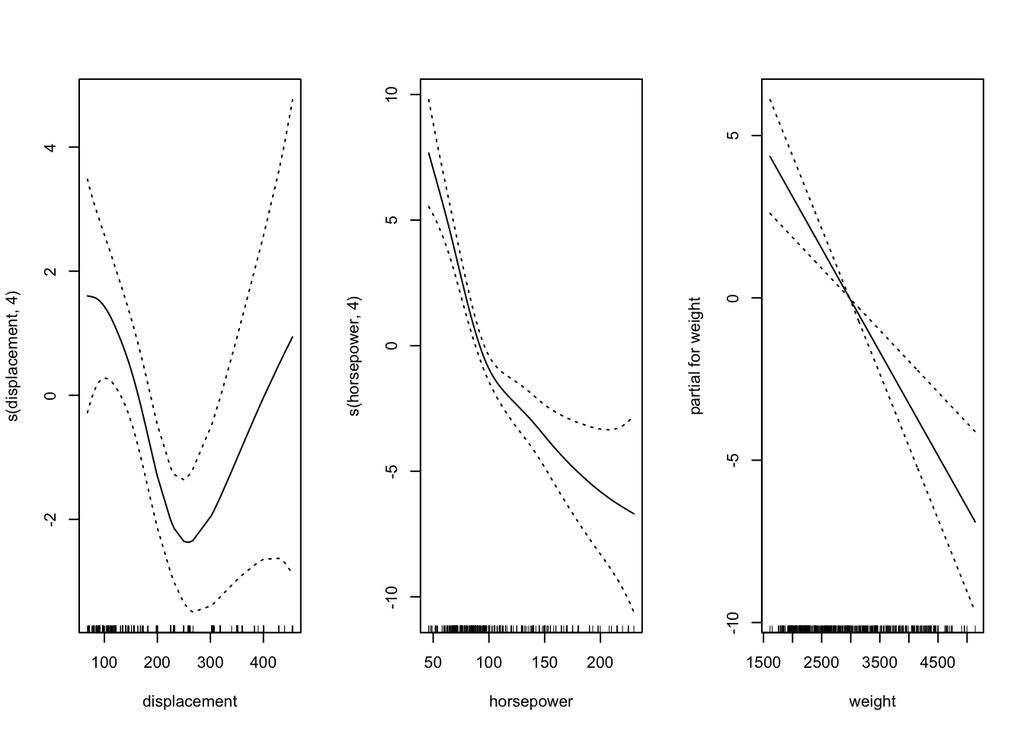

```r
par(mfrow=c(1,3))
plot(fit,se=T)
```

from Anova, weight appears to be a linear predictor

### Ex 9

#### a)

```r
require(MASS)
```

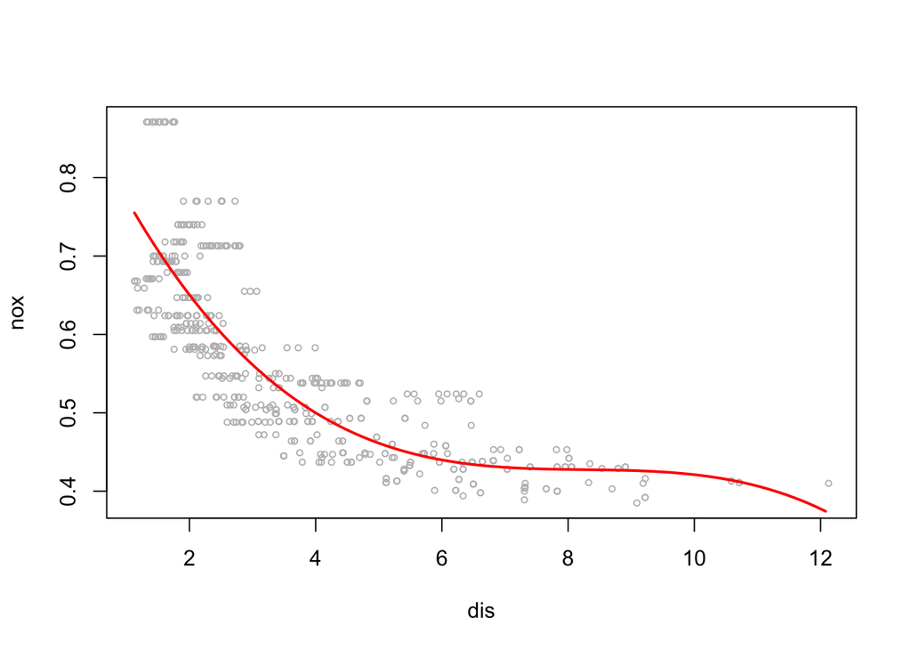

```r
attach(Boston)
fit.1 <- lm(nox~poly(dis,3), data=Boston)
dis.grid <- seq(range(dis)[1], range(dis)[2], by=0.05)
preds <- predict(fit.1, newdata=data.frame(dis=dis.grid), se=T )
plot(nox~dis,data=Boston,cex=0.6,col="gray")
lines(dis.grid, preds$fit, lwd=2, col="red")
```

##### b)

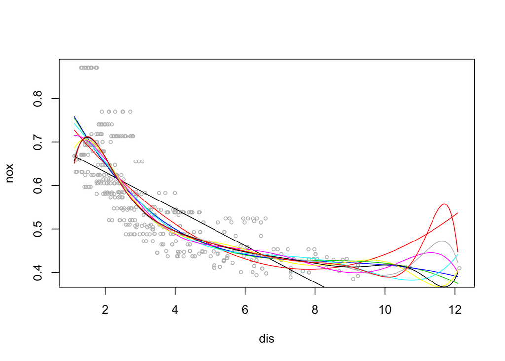

```r
rss<-rep(NA,10)
fits <- list()
preds <- list()
plot(nox~dis,data=Boston,cex=0.6,col="gray")
for (d in 1:10){
  fits[[d]] <- lm(nox~poly(dis,d), data=Boston)
  rss[d] <- deviance(fits[[d]])
  #rss[d] <- sum(fits[[d]]$residuals^2) #same result
  preds[[d]] <- predict(fits[[d]], newdata=list(dis=dis.grid))
  lines(dis.grid, preds[[d]], lwd=1, col=d)
}
```

```r
print(rss)
```

```
##  [1] 2.768563 2.035262 1.934107 1.932981 1.915290 1.878257 1.849484
##  [8] 1.835630 1.833331 1.832171
```

As expected, train RSS decreases monotonically, the df=3 is sufficient for the dis predictor.

#### c)

```r
set.seed(1)
cv.errs <- rep(NA,10)
for (d in 1:10){
  fit <- glm(nox~poly(dis,d), data=Boston)
  cv.errs[d] <- cv.glm(Boston, fit, K=10)$delta[2]
}
print( which.min(cv.errs) )
```

```
## [1] 4
```

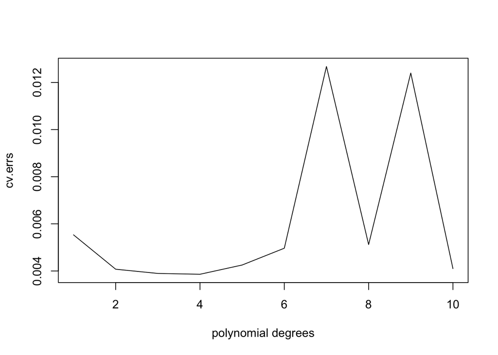

```r
plot(cv.errs, type="l", xlab="polynomial degrees")
```

10-fold X-validation chooses the `df=4`

### d)

```r
require(splines)
fit <- lm(nox~bs(dis,df=4, knots=c(3,6,8)), data=Boston)
summary(fit)
```

```
##
## Call:
## lm(formula = nox ~ bs(dis, df = 4, knots = c(3, 6, 8)), data = Boston)
##
## Residuals:
##       Min        1Q    Median        3Q       Max
## -0.132406 -0.038970 -0.009732  0.025620  0.187718
##
## Coefficients:
##                                      Estimate Std. Error t value Pr(>|t|)
## (Intercept)                           0.70803    0.01617  43.794  < 2e-16
## bs(dis, df = 4, knots = c(3, 6, 8))1  0.00953    0.02578   0.370    0.712
## bs(dis, df = 4, knots = c(3, 6, 8))2 -0.26101    0.01816 -14.375  < 2e-16
## bs(dis, df = 4, knots = c(3, 6, 8))3 -0.22973    0.02576  -8.920  < 2e-16
## bs(dis, df = 4, knots = c(3, 6, 8))4 -0.33005    0.03047 -10.832  < 2e-16
## bs(dis, df = 4, knots = c(3, 6, 8))5 -0.26763    0.06039  -4.432 1.15e-05
## bs(dis, df = 4, knots = c(3, 6, 8))6 -0.30598    0.06071  -5.040 6.52e-07
##
## (Intercept)                          ***
## bs(dis, df = 4, knots = c(3, 6, 8))1
## bs(dis, df = 4, knots = c(3, 6, 8))2 ***
## bs(dis, df = 4, knots = c(3, 6, 8))3 ***
## bs(dis, df = 4, knots = c(3, 6, 8))4 ***
## bs(dis, df = 4, knots = c(3, 6, 8))5 ***
## bs(dis, df = 4, knots = c(3, 6, 8))6 ***
## ---
## Signif. codes:  0 '***' 0.001 '**' 0.01 '*' 0.05 '.' 0.1 ' ' 1
##
## Residual standard error: 0.06117 on 499 degrees of freedom
## Multiple R-squared:  0.7247, Adjusted R-squared:  0.7214
## F-statistic: 218.9 on 6 and 499 DF,  p-value: < 2.2e-16
```

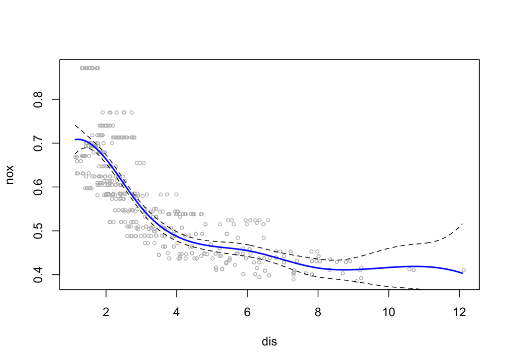

```r
pred <- predict(fit, newdata=list(dis=dis.grid), se=T )
plot(nox~dis,data=Boston,cex=0.6,col="gray")
lines(dis.grid,pred$fit,lwd=2, col="blue")
lines(dis.grid,pred$fit+2*pred$se ,lty="dashed")
lines(dis.grid,pred$fit-2*pred$se ,lty="dashed")
```

Knots were chosen from the visual aspect of the data.

##### e)

```r
rss <- rep(NA,14)
for (df in 3:14){
  fit <- glm(nox~bs(dis,df=df), data=Boston)
  rss[df] <- sum(fit$residuals^2)
}
print( rss[-c(1,2)] )
```

```
##  [1] 1.934107 1.922775 1.840173 1.833966 1.829884 1.816995 1.825653
##  [8] 1.792535 1.796992 1.788999 1.782350 1.781838
```

#### f)

```r
options(warn=-1)
cv.errs <- rep(NA,14)
for (df in 3:14){
  fit <- glm(nox~bs(dis,df=df), data=Boston)
  cv.errs[df] <- cv.glm(Boston, fit, K=10)$delta[2]
}
print( which.min(cv.errs) )
```

```
## [1] 10
```

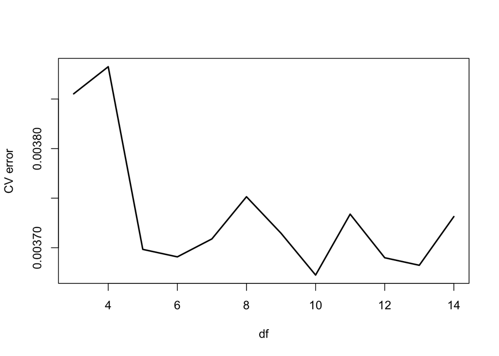

```r
plot(3:14, cv.errs[-c(1, 2)], lwd = 2, type = "l", xlab = "df", ylab = "CV error")
```